# statistic2_final_project7

```python
import matplotlib.pyplot as plt
%matplotlib inline
import matplotlib
import math
import numpy as np
import pandas as pd
import scipy.stats as stats
import statsmodels.api as sm
import statsmodels.stats.api as sms
import statsmodels.formula.api as smf
import statsmodels.stats.multicomp as smm
import statsmodels.stats.libqsturng as slb
import statsmodels
import seaborn as sns
import statsmodels.stats.outliers_influence as sso
import statistics
from itertools import groupby, chain, combinations
from statsmodels.tsa.api import Holt
from functools import reduce

import warnings
plt.style.use("default")
plt.rcParams.update({"figure.dpi": 70, "axes.titlesize": 16, "axes.labelsize": 13, "font.size": 11})
matplotlib.rc('font', family='Microsoft JhengHei')  # Chinese Font ==
```

```python
class myANOVA:
    def __init__(self, data, method="one-way"):  # input needs to be melted
        if method not in ["one-way", "rand-block", "two-factor"]:
            raise NotImplementedError("Error: Only supports 'one-way', 'rand-block', or 'two-factor' ANOVA")
        if "Value" not in data.columns:
            raise RuntimeError("Error: 'Value' is not a column in data.")

        self.data = data.copy()
        self.method = method
        self.anova_table = pd.DataFrame()


    def data_summary(self, by):
        print("="*70)
        print("Descriptive Statistics for All Treatments:")
        display(self.data.groupby(by)["Value"].describe()[["count", "mean", "std"]])


    def required_condition_summary(self, by):
        cols = list(sorted(set(self.data[by])))

        self.data.hist(by=by, column="Value", bins=5)  # Histogram
        print("="*70)
        print("Histograms for All Treatments:")
        plt.show()

        for i, col in enumerate(cols): # Q-Q Plot
            if i%2 == 0: fig = plt.figure(figsize=(9.5, 4))
            ax = plt.subplot(1, 2, i%2 + 1)
            sm.qqplot(self.data[self.data[by] == col]["Value"].dropna(), stats.norm, fit=True, line='45', ax=ax)
            ax.set_box_aspect(1)
            plt.title(f"Q-Q Plot for {col}")
            if i%2 == 1 or i == len(cols) - 1: plt.show()

        print("Shapiro Test:")  # Shapiro Test
        sh_df = pd.DataFrame(columns=cols, index=["shapiro stat", "p value"])
        for col in cols:
            shapiro_stat, sh_p_val = stats.shapiro(self.data[self.data[by] == col]["Value"].dropna())
            sh_df[col]["shapiro stat"] = shapiro_stat
            sh_df[col]["p value"] = sh_p_val
            if sh_p_val < .05: warnings.warn(f"Warning: Shapiro Test suggests that the distribution of {col} is not normal. (alpha=.05)")
        display(sh_df)

        print("Bartlett Test:")  # Bartlett Test
        ba_df = pd.DataFrame(columns=["All Treatments"], index=["bartlett stat", "p value"])
        bartlett_stat, bartlett_p_val = stats.bartlett(*[self.data[self.data[by] == col]["Value"].dropna() for col in cols])
        ba_df["All Treatments"]["bartlett stat"] = bartlett_stat
        ba_df["All Treatments"]["p value"] = bartlett_p_val
        if bartlett_p_val < .05: warnings.warn(f"Warning: Bartlett Test suggests that the variances of treatments are unequal. (alpha=.05)")
        display(ba_df)


    def anova_summary(self, by, hide_result=False):
        if not hide_result: print("="*70)
        if self.method == "one-way":  # One-Way ANOVA
            if not hide_result:
                print("One-Way ANOVA Table:")
            data_ols = smf.ols(f"Value ~ C({by})", data=self.data).fit()
        elif self.method == "rand-block":  # randomized block ANOVA
            if not hide_result:
                print("Randomized Block ANOVA Table:")
            data_ols = smf.ols(f"Value ~ C({by[0]}) + C({by[1]})", data=self.data).fit()
        else:  # Two-Factor ANOVA
            if not hide_result:
                print("Two-Factor ANOVA Table:")
            data_ols = smf.ols(f"Value ~ C({by[0]}) + C({by[1]}) + C({by[0]}):C({by[1]})", data=self.data).fit()
        anova_table = sms.anova_lm(data_ols, typ=2)
        anova_table.insert(2, "mean_sq", anova_table["sum_sq"] / anova_table["df"])  # compute MST and MSE
        anova_table.loc["Total"] = anova_table.sum(axis=0, skipna=False)             # compute SS and df
        anova_table["mean_sq"]["Total"] = np.nan
        if not hide_result: display(anova_table)
        self.anova_table = anova_table


    def multiple_comp_summary(self, by, alpha, method="Tukey"):
        if self.method != "one-way":
            raise RuntimeError("Error: Multiple comparisons available only with one-way ANOVA.")
        if method not in ["Fisher", "Tukey"]:
            raise NotImplementedError("Error: method must be 'Tukey' or 'Fisher'.")
        if self.anova_table.empty:
            raise RuntimeError("Error: Please perform anova_summary() before multiple comparisons.")

        cols = list(sorted(set(self.data[by])))
        descr_stat = self.data.groupby(by)["Value"].describe()[["count", "mean"]]
        mse = self.anova_table["mean_sq"]["Residual"]
        mse_df = self.anova_table["df"]["Residual"]
        multiple_comp_df = pd.DataFrame(columns=["Treatment 1", "Treatment 2", "Mean Diff", "LSD or Omega", "Rejected"])
        for (i, t1) in enumerate(cols):
            for (j, t2) in enumerate(cols):
                if j <= i: continue

                if method == "Fisher":
                    LSD = stats.t.isf(alpha/2, mse_df) * math.sqrt(mse * (1/descr_stat["count"][t1] + 1/descr_stat["count"][t2]))
                if method == "Tukey":
                    k_treatments = len(cols)
                    n_group = stats.hmean(descr_stat["count"])  # harmonic mean
                    LSD = slb.qsturng(1 - alpha, k_treatments, mse_df) * math.sqrt(mse / n_group)
                mean_diff = descr_stat["mean"][t1] - descr_stat["mean"][t2]
                multiple_comp_df.loc[len(multiple_comp_df)] = [t1, t2, mean_diff, LSD, (abs(mean_diff) > LSD)]

        print("="*70)
        print(f"Comparison Method: {method}")
        print(f"alpha = {alpha:.4f}")
        # display(multiple_comp_df)
        return multiple_comp_df


    def anova_pipeline(self, by):  # CAUTION!!! Always put factor I in index 0.
        if self.method == "one-way":
            self.data_summary(by=by)
            self.required_condition_summary(by=by)
            self.anova_summary(by=by)
        elif self.method == "rand-block":
            self.data_summary(by=by[0])
            self.required_condition_summary(by=by[0])
            self.anova_summary(by=by)
        else:  # two-factor
            if f"{by[0]}_{by[1]}" not in self.data.columns:  # create joint factor column
                self.data[f"{by[0]}_{by[1]}"] = [f"{f0}_{f1}" for f0, f1 in zip(self.data[by[0]], self.data[by[1]])]
            self.data_summary(by=by[0])
            self.data_summary(by=by[1])
            self.required_condition_summary(by=f"{by[0]}_{by[1]}")
            self.anova_summary(by=by)


    def multiple_comp_only_pipeline(self, by, alpha, method="Tukey"):
        if self.anova_table.empty:
            self.anova_summary(by=by, hide_result=True)
        return self.multiple_comp_summary(by=by, alpha=alpha, method=method)
```

```python
class MyChi2Test:
    @staticmethod
    def goodness_of_fit(freq_o, prop_e, ddof=0):  # observed, expected
        if np.sum(prop_e) < 0.9999:
            warnings.warn("Warning: Expected proportions do not add to 1.")
        sample_size = np.sum(freq_o)
        freq_e = np.array(prop_e) * sample_size

        e_o_df = pd.DataFrame({"Observed": freq_o, "Expected": freq_e})
        e_o_df = e_o_df.transpose()
        display(e_o_df)

        if (freq_e < 5).any():
            raise RuntimeError("Error: Rule of Five is violated.")
        chi2_val, p_val = stats.chisquare(freq_o, freq_e, ddof=ddof)
        chi2_test_df = pd.DataFrame({"Chi2": [chi2_val], "p value": [round(p_val, 4)]}, index=["Value"])
        display(chi2_test_df)


    @staticmethod
    def cont_table(freq_o):  # observed
        chi2_val, p_val, _, freq_e = stats.chi2_contingency(freq_o, correction=False)
        print("Expected Frequencies:")
        display(pd.DataFrame(np.round(freq_e, 2), columns=freq_o.columns, index=freq_o.index))

        if (freq_e < 5).any():
            raise RuntimeError("Error: Rule of Five is violated.")
        chi2_test_df = pd.DataFrame({"Chi2": [chi2_val], "p value": [round(p_val, 4)]}, index=["Value"])
        display(chi2_test_df)


    @staticmethod
    def check_normality(data, nbins, figsize=(9, 5)):  # nbins: number of equal-probability bins
        data_mean, data_std = [np.mean(data), np.std(data, ddof=1)]

        INF = 0x3f3f3f3f
        prop_e = [1 / nbins] * nbins
        bins = [-INF] + [stats.norm.ppf(i / nbins, loc=data_mean, scale=data_std) for i in range(1, nbins)] + [INF]

        freq_o, _ = np.histogram(data, bins)  # counting frequencies of each bin
        plt.figure(figsize=figsize)
        plt.title("Observed Frequencies in Equal Probability Intervals")  # plotting observed freqs
        xticks = [f"(-INF, {bins[1]:,.2f}]"] + [f"[{bins[i]:,.2f}, {bins[i+1]:,.2f}]" for i in range(1, len(bins) - 2)] + [f"[{bins[len(bins) - 2]:,.2f}, INF)"]
        plt.bar(xticks, freq_o)
        plt.xlabel("Interval")
        plt.ylabel("Frequency")
        plt.axhline(y=prop_e[0]*len(data), color='r', label="Expected Frequency")
        plt.legend()
        plt.show()

        MyChi2Test.goodness_of_fit(freq_o, prop_e, ddof=2)  # remember ddof = 2
class MyMultipleRegr:
    def __init__(self, data, by, func=(lambda x: x)):  # by: [y, x_1, x_2, ..., x_k]
        self.by = by
        self.data = data
        self.k = len(by[1:])
        self.func = func

        X_mat = data[by[1:]]
        X_mat = sm.add_constant(X_mat)  # add intercept term
        y_vec = data[by[0]].apply(func)
        self.regr_result = sm.OLS(y_vec, X_mat).fit()

        # standardized residuals & outliers
        _, self.regr_summ_table, _ = sso.summary_table(self.regr_result, alpha=.05)
        self.std_resid = self.regr_summ_table[:, 10]
        self.outlier_filter = (abs(self.std_resid) > 2)

        # hinge & influential observations
        X_mat = X_mat.to_numpy()
        H_mat = np.dot(X_mat, np.linalg.solve(np.dot(X_mat.T, X_mat), X_mat.T))
        self.hinge = np.diagonal(H_mat)
        self.influential_filter = (self.hinge > (3 * (self.k + 1)) / len(self.data))

        # cook's distance & influential observations (does not apply to SLR)
        if self.k > 1:
            y_resid = self.regr_summ_table[:, 8]
            mse_resid = self.regr_result.mse_resid
            self.cook_dist = (y_resid**2) / (self.k - 1) / mse_resid * self.hinge / (1 - self.hinge)**2
            self.cook_influential_filter = (self.cook_dist > 1)


    def summary(self):
        print(self.regr_result.summary())
        print("\n==============================================================================")
        if self.k == 1:
            print(f"Testing Correlation Coefficient Between {self.by[0]} and {self.by[1]}:")
            corrcoef, p_val = stats.pearsonr(self.data[self.by[1]], self.data[self.by[0]].apply(self.func))
            cc_df = pd.DataFrame(columns=["Pearson r", "p value"], index=["Value"])
            cc_df["Pearson r"]["Value"] = round(corrcoef, 4)
            cc_df["p value"]["Value"] = round(p_val, 4)
            display(cc_df)

        print(f"Mean of {self.by[0]} = {self.regr_summ_table[:, 1].mean():.4f}")
        print(f"Standard Error of Estimate = {math.sqrt(self.regr_result.mse_resid):.4f}")

        print("\nANOVA Table for Regression")
        anova_df = pd.DataFrame(columns=["SS", "DF", "MS", "F", "p value"], index=["Regression", "Errors", "Total"])
        anova_df["F"]["Regression"] = self.regr_result.fvalue
        anova_df["p value"]["Regression"] = self.regr_result.f_pvalue
        anova_df["MS"]["Regression"] = self.regr_result.fvalue * self.regr_result.mse_resid
        anova_df["DF"]["Regression"] = self.k
        anova_df["MS"]["Errors"] = self.regr_result.mse_resid
        anova_df["DF"]["Errors"] = int(self.regr_result.df_resid)
        anova_df["SS"] = anova_df["MS"] * anova_df["DF"]
        anova_df.loc["Total"] = anova_df.loc["Regression"] + anova_df.loc["Errors"]
        anova_df["MS"]["Total"] = np.nan
        display(anova_df)


    def scatter(self):  # also finds outliers and influential obs
        print("="*70)
        for i, x_indep in enumerate(self.by[1:]):
            if i % 2 == 0: plt.figure(figsize=(8, 3))
            ax = plt.subplot(1, 2, (i % 2) + 1)
            plt.title(f"{x_indep} and {self.by[0]}")
            plt.scatter(self.data[x_indep], self.data[self.by[0]], color='gray')
            plt.scatter(self.data[x_indep][self.outlier_filter],
                            self.data[self.by[0]][self.outlier_filter], label="outlier", color='brown')
            plt.scatter(self.data[x_indep][self.influential_filter],
                            self.data[self.by[0]][self.influential_filter], label="influential", color='tab:cyan')
            if self.k > 1:
                plt.scatter(self.data[x_indep][self.cook_influential_filter],
                            self.data[self.by[0]][self.cook_influential_filter], label="cook influential", color='tab:blue')
            plt.xlabel(x_indep)
            plt.ylabel(self.by[0])
            plt.grid()
            box = ax.get_position()
            ax.set_position([box.x0, box.y0, box.width * 0.9, box.height])
            if i % 2 or x_indep == self.by[-1]:
                ax.legend(loc='center left', bbox_to_anchor=(1, 0.5))
                plt.show()
```

```python
        print("Outliers:")
        display(pd.Series(self.std_resid, name="Standardized Residual").loc[self.outlier_filter])
        print("\nInfluential Observations:")
        display(pd.Series(self.hinge, name="Hinge").loc[self.influential_filter])
        if self.k > 1:
            print("\nCook's Influential Observations:")
            display(pd.Series(self.cook_dist, name="Cook's Distance").loc[self.cook_influential_filter])


    def slope_ci(self, index, alpha):
        print("="*50)
        print(f"Confidence Interval for {self.by[index]}'s Coefficient")
        slope_ci = self.regr_result.conf_int(alpha).loc[self.by[index]]

        interval_df = pd.DataFrame(columns=[f"[{alpha/2:.4f}", f"{1 - alpha/2:.4f}]"], index=["confidence"])
        interval_df[f"[{alpha/2:.4f}"]["confidence"] = round(slope_ci[0], 4)
        interval_df[f"{1 - alpha/2:.4f}]"]["confidence"] = round(slope_ci[1], 4)
        display(interval_df)


    def y_ci_pi(self, x_given, alpha, inverse_func=(lambda x: x)):
        print("="*70)
        print(f"Confidence & Prediction Intervals for x = {x_given}")
        pred = self.regr_result.get_prediction([1] + x_given).summary_frame(alpha=alpha)  # 1 is intercept

        interval_df = pd.DataFrame(columns=[f"[{alpha/2:.4f}", f"{1 - alpha/2:.4f}]"], index=["confidence", "prediction"])
        interval_df[f"[{alpha/2:.4f}"]["confidence"] = pred["mean_ci_lower"][0]
        interval_df[f"[{alpha/2:.4f}"]["prediction"] = pred["obs_ci_lower"][0]
        interval_df[f"{1 - alpha/2:.4f}]"]["confidence"] = pred["mean_ci_upper"][0]
        interval_df[f"{1 - alpha/2:.4f}]"]["prediction"] = pred["obs_ci_upper"][0]
        interval_df = interval_df.applymap(inverse_func)  # use map() for future versions
        interval_df = interval_df.applymap(np.round, decimals=4)
        display(interval_df)


    ######### Residual Analysis #########
    def resid_normality_test(self, method="chisquare", nbins=None, figsize=(9, 5)):
        print("="*70)
        if method == "chisquare":
            print(f"Goodness-of-Fit Test for Standardized Residuals")
            MyChi2Test.check_normality(self.std_resid, nbins=nbins, figsize=figsize)
        elif method == "shapiro":
            sm.qqplot(self.std_resid, stats.norm, fit=True, line='45')
            plt.title("Q-Q Plot for Standardized Residuals")
            plt.show()

            sh_df = pd.DataFrame(columns=["shapiro stat", "p value"], index=["Value"])
            shapiro_stat, sh_p_val = stats.shapiro(self.std_resid)
            sh_df["shapiro stat"]["Value"] = shapiro_stat
            sh_df["p value"]["Value"] = sh_p_val
            display(sh_df)
        else:
            raise RuntimeError("Error: Only accepts 'chisquare' or 'shapiro' for method")


    def residual_plot(self):  # test for homoscedasticity and outliers
        print("="*50)
        print(f"Checking Homoscedasticity with Residual Plot")
        y_pred = self.regr_summ_table[:, 2]

        plt.title("Standardized Residual Plot")
        plt.scatter(y_pred, self.std_resid, color='gray')
        plt.scatter(y_pred[self.outlier_filter], self.std_resid[self.outlier_filter], label="outlier", color='brown')
        plt.axhline(y=0, color = 'blue')
        plt.axhline(y=2, color = 'red')
        plt.axhline(y=-2, color = 'red')
        plt.xlabel(f"Predicted {self.by[0]}")
        plt.ylabel("Standardized Residual")
        plt.legend()
        plt.show()


    def resid_autocorr_test(self):  # test for autocorrelation using runs test
        print("="*50)
        print(f"Runs Test for Standardized Residuals")

        std_resid_median = np.median(self.std_resid)
        std_resid_ind = (self.std_resid >= std_resid_median)
        n_greater = np.sum(std_resid_ind)
        n_less = (len(self.std_resid) - n_greater)
        runs = len([i for i, _ in groupby(std_resid_ind)])

        norm_mean = 2*n_greater*n_less / (n_greater + n_less) + 1
        norm_std = (math.sqrt(2*n_greater*n_less) * math.sqrt((2*n_greater*n_less - n_greater - n_less))
                                 / math.sqrt((n_greater + n_less)**2) / math.sqrt((n_greater + n_less - 1)))

        z_stat = (runs - norm_mean) / norm_std
        p_val = min(stats.norm.cdf(z_stat), 1 - stats.norm.cdf(z_stat))
        runs_df = pd.DataFrame(columns=["# >= Median", "# < Median", "Runs", "Z stat", "p value"], index=["Value"])
        runs_df["# >= Median"]["Value"] = n_greater
        runs_df["# < Median"]["Value"] = n_less
        runs_df["Runs"]["Value"] = runs
        runs_df["Z stat"]["Value"] = z_stat
        runs_df["p value"]["Value"] = round(p_val*2, 4)  # two-tail
        display(runs_df)


    def residual_analysis_pipeline(self, method="chisquare", nbins=None, figsize=(9, 5)):
        self.resid_normality_test(method, nbins, figsize)
        self.residual_plot()
        self.resid_autocorr_test()


    ######### Regression Diagnostics #########
    def diag_multicoll(self):
        print("="*50)
        plt.title("Heatmap for Correlation Coefficients")
        corr_mat = self.data[self.by].corr()
        sns.heatmap(corr_mat, annot=True)
        plt.show()
        for i in self.by[1:]:
            for j in self.by[1:]:
                if i == j: continue
                if np.sum(corr_mat[i][j] > 0.7):  # explicit multicollinearity
                    warnings.warn("Warning: Some correlation coefficients between independent variables have exceeded 0.7...")

        corr_coef_df = pd.DataFrame(columns=self.by[1:], index=["r", "coef"])
        corr_coef_df.loc["r"] = corr_mat.iloc[0, 1:]
        corr_coef_df.loc["coef"] = self.regr_result.params[1:]
        print("Comparing correlation coefficients and regression coefficients:")
        display(corr_coef_df)
        if np.sum(corr_coef_df.loc["r"]*corr_coef_df.loc["coef"] < 0):  # implicit multicollinearity
            warnings.warn("Warning: Some signs of r is inconsistent with those of the coefficients...")


    def diag_autocorr(self):  # test for autocorrelation using Durbin-Waston
        print("="*50)
        plt.title("Standardized Residuals Ordered by Sample #")
        plt.plot(self.regr_summ_table[:, 0], self.std_resid, '-o', color='gray')
        plt.axhline(y=0, color='blue')
        plt.xlabel("Sample #")
        plt.ylabel("Standardized Residual")
        plt.show()
```

```python
        std_resid_cut = self.std_resid[1:]
        std_resid_rolled = np.roll(self.std_resid, 1)[1:]
        dw_stat = np.sum((std_resid_cut - std_resid_rolled)**2) / np.dot(self.std_resid, self.std_resid)
        print(f"Durbin-Waston statistic = {dw_stat:.4f}")


    def diagnostics_pipeline(self):
        self.diag_multicoll()
        self.diag_autocorr()
class MyMBUtilities:
    @staticmethod
    def sns_scatter(data, y, x, orders=[], logistic=False, stratify_by=None, scatter=True):  # x is a list
        '''
        :param stratify_by: the indepedent variable name whose values are used to stratify observations
        '''
        if stratify_by:
            val_set = set(data[stratify_by])
            data_dict = {i: data[data[stratify_by] == i] for i in val_set}

        if len(orders) == 0:  # default: linear model
            orders = [1] * len(x)

        for i, x_indep in enumerate(x):
            if stratify_by:
                for val, stratum in data_dict.items():
                    _ = sns.regplot(data=stratum, x=x_indep, y=y, ci=None, scatter=scatter,
                                        order=orders[i], logistic=logistic,
                                        label=x_indep + f" ({stratify_by} = {val})")
            else:
                _ = sns.regplot(data=data, x=x_indep, y=y, ci=None, scatter=scatter,
                                    order=orders[i], logistic=logistic,
                                    label=x_indep)

        plt.title(f"Scatter Plot for {y} and {', '.join(x)}")
        plt.xlabel(', '.join(x))
        plt.ylabel(y)
        plt.legend()
        plt.grid()
        plt.show()


    @staticmethod
    def add_dummies(data, x):  # x is the name of a qualitative column
        dummy_df = pd.get_dummies(data[x], prefix=x).astype(float)
        data = pd.concat([data, dummy_df], axis=1)
        return data


    @staticmethod
    def add_interaction(data, x1, x2):
        data[f"{x1}:{x2}"] = data[x1] * data[x2]
        return data


    @staticmethod
    def add_previous(data, x, periods):
        data[f"{x}_{periods}"] = data[x].shift(periods)
        return data.dropna()


    @staticmethod
    def stepwise(data, by, alpha, direction):  # by = [y, x_1, ...]
        if direction not in ["forward", "backward"]:
            raise RuntimeError("Error: direction should be either 'forward' or 'backward'")

        X_mat = data[by[1:]]
        X_mat = sm.add_constant(X_mat)  # add intercept term
        y_vec = data[by[0]]
        if direction == "forward":
            result = step_reg.forward_regression(X_mat, y_vec, alpha, verbose=False)
        else:
            result = step_reg.backward_regression(X_mat, y_vec, alpha, verbose=False)

        print(f"{direction.capitalize()} Stepwise Regression Result: {result}")
        return result[1:]


    @staticmethod
    def best_subsets(data, by, top_k=5):  # top-k: how many best subsets are returned
        by_powerset = list(chain.from_iterable(combinations(by[1:], i) for i in range(1, len(by[1:])+1)))
        subset_rsq_df = pd.DataFrame(columns=["Subset", "Adj. Rsq"])

        for by_subset in by_powerset:  # enumerate all possible subsets
            X_mat = data[list(by_subset)]
            X_mat = sm.add_constant(X_mat)
            y_vec = data[by[0]]
            adj_rsq = sm.OLS(y_vec, X_mat).fit().rsquared_adj
            subset_rsq_df.loc[len(subset_rsq_df)] = [list(by_subset), adj_rsq]

        # sort w.r.t. the adjusted rsquared values
        subset_rsq_df = subset_rsq_df.sort_values(by=["Adj. Rsq"], ascending=False).reset_index(drop=True)
        print("Best-Subsets Regression Result:")
        display(subset_rsq_df.iloc[:top_k])
        return subset_rsq_df["Subset"][:top_k]

class MyTrendAnalysis:
    def __init__(self, data, by):
        self.data = data.copy()
        self.data.loc[len(data)] = np.nan  # append an empty row for forecast
        self.by = by


    # Smoothing Techniques
    def MA(self, window):
        self.data.drop(columns="MA", inplace=True, errors="ignore")
        self.data["MA"] = self.data[self.by].rolling(window).mean().shift(1)


    def ES(self, alpha):
        self.data.drop(columns="ES", inplace=True, errors="ignore")
        self.data["ES"] = self.data[self.by].ewm(alpha=alpha, adjust=False).mean().shift(1)
        self.data["ES"][0] = self.data[self.by][0]  # initial value


    def EST(self, alpha, beta, est_0, et_0):
        self.data.drop(columns="EST", inplace=True, errors="ignore")
        est = Holt(self.data[self.by].dropna(), initialization_method='known',
                   initial_level=est_0, initial_trend=et_0).fit(
                        smoothing_level=alpha, smoothing_trend=beta, optimized=False)
        self.data.drop(columns="EST", inplace=True, errors="ignore")
        self.data["EST"] = est.fittedvalues
        self.data["EST"].iloc[-1] = est.forecast(1)


    def EST_multiperiod(self, alpha, beta, est_0, et_0, period):
        est = Holt(self.data[self.by].dropna(), initialization_method='known',
                   initial_level=est_0, initial_trend=et_0).fit(
                        smoothing_level=alpha, smoothing_trend=beta, optimized=False)
        est_df = pd.DataFrame(columns=[self.by, "EST"])
        est_df["EST"] = pd.concat([est.fittedvalues, est.forecast(period)])
        est_df[self.by] = self.data[self.by]

        print("\nMultiple Period Forecast with EST:")
        display(est_df.tail())


    # Regression, returns MyMultipleRegr object
    def linear_regression(self):
        self.data["Regression"] = np.nan
        data_with_t = self.data[[self.by]].dropna()
        data_with_t["Time"] = data_with_t.index
        regr = MyMultipleRegr(data=data_with_t, by=[self.by, "Time"])

        for i in range(len(self.data)):
            self.data["Regression"][i] = regr.regr_result.predict([1, i])
        return regr


    def quadratic_regression(self):
        self.data["Regression"] = np.nan
        data_with_t = self.data[[self.by]].dropna()
        data_with_t["Time"] = data_with_t.index
        data_with_t["Time_sq"] = data_with_t["Time"]**2
        regr = MyMultipleRegr(data=data_with_t, by=[self.by, "Time", "Time_sq"])
```

```python
        for i in range(len(self.data)):
            self.data["Regression"][i] = regr.regr_result.predict([1, i, i**2])
        return regr


    # Error Metrics
    def error_metrics(self):
        err_df = pd.DataFrame(index=["MAD", "MSE", "MAPE (%)"])
        data_nna = self.data.dropna()  # only evaluate mutually available rows

        for smth in ["MA", "ES", "EST", "Regression"]:
            if smth not in data_nna.columns: continue
            err = data_nna[smth] - data_nna[self.by]
            err_df[smth] = np.nan
            err_df[smth]["MAD"]      = np.mean(np.absolute(err))
            err_df[smth]["MSE"]      = np.mean(err**2)
            err_df[smth]["MAPE (%)"] = np.mean(np.absolute(err) / data_nna[self.by] * 100)

        err_df = err_df.applymap(np.round, decimals=4)  # use map() for future versions
        print("\nError Metrics Table:")
        display(err_df)


    # Summarize with Dataframe and Line Chart
    def summary(self):
        print("\nDataframe Overview:")
        display(self.data.head())
        display(self.data.tail())

        _, ax = plt.subplots()
        plt.title(f"Line Chart for {self.by}")
        plt.plot(self.data.index, self.data[self.by], label="Real")
        for smth in ["MA", "ES", "EST", "Regression"]:
            if smth not in self.data.columns: continue
            plt.plot(self.data.index, self.data[smth], label=smth)
        plt.xlabel("Time")
        plt.ylabel(self.by)
        plt.grid()
        box = ax.get_position()
        ax.set_position([box.x0, box.y0, box.width * 0.9, box.height])
        ax.legend(loc='center left', bbox_to_anchor=(1, 0.5))
        plt.show()
class MySeasonalAnalysis:
    def __init__(self, data, by, season_len, start_season=1):
        self.data = data.copy()
        for i in range(season_len):
            self.data.loc[len(self.data)] = np.nan  # append empty rows for forecast
        self.data["Season"] = (self.data.index + start_season - 1) % season_len + 1
        self.data["Time"] = self.data.index
        self.by = by
        self.start_season = start_season
        self.season_len = season_len


    def CMA(self, normality_method="shapiro", nbins=None):
        # calculate CMA
        self.data["CMA"] = self.data[self.by].rolling(window=self.season_len, center=True).mean()
        if self.season_len % 2 == 0:  # need to roll twice if the season length is even
            self.data["CMA"] = self.data["CMA"].rolling(window=2).mean().shift(-1)

        # compute seasonal effect and seasonal index
        self.data["CMA_seasonal_eff"] = self.data[self.by] / self.data.CMA
        seasonal_idx = self.data.groupby("Season")[["CMA_seasonal_eff"]].mean()
        seasonal_idx.columns = ["CMA_seasonal_index"]
        seasonal_idx = seasonal_idx * self.season_len / seasonal_idx.sum()
        assert abs(seasonal_idx.sum().values - self.season_len) < 0.000001
        display(seasonal_idx)

        # compute deseasonalized data
        self.data = self.data.merge(seasonal_idx.reset_index()).sort_values("Time").reset_index(drop=True)
        self.data["CMA_deseasoned"] = self.data[self.by] / self.data.CMA_seasonal_index

        # regression
        print("Performing Regression on Deseasonalized Data...")
        cma_regr = MyMultipleRegr(self.data[["CMA_deseasoned", "Time"]].dropna(), by=["CMA_deseasoned", "Time"])
        cma_regr.residual_analysis_pipeline(method=normality_method, nbins=nbins)
        cma_regr.diag_autocorr()
        cma_regr.summary()

        # forecasting
        self.data["CMA_pred"] = np.nan
        for i in range(len(self.data)):
            self.data.loc[i, "CMA_pred"] = cma_regr.regr_result.predict([1, self.data["Time"][i]]) * self.data.loc[i, "CMA_seasonal_index"]

        # plotting
        plt.plot(self.data.Time, self.data[self.by], label="Real")
        plt.plot(self.data.Time, self.data.CMA_deseasoned, label=f"Deseason")
        plt.plot(self.data.Time, self.data.CMA_pred, label=f"Predict")
        plt.xlabel("Time")
        plt.ylabel(self.by)
        plt.title(f"{self.season_len}-CMA Seasonal Analysis of {self.by}")
        plt.legend()
        plt.grid()
        plt.show()

        display(self.data[["Time", "CMA_pred"]].tail(self.season_len))


    def LR(self, normality_method="shapiro", nbins=None):
        # initial linear regression
        init_regr = MyMultipleRegr(self.data[[self.by, "Time"]].dropna(), by=[self.by, "Time"])
        self.data["Regr"] = np.concatenate((init_regr.regr_summ_table[:, 2], np.array([np.nan]*self.season_len)))

        # compute seasonal effect and seasonal index
        self.data["LR_seasonal_eff"] = self.data[self.by] / self.data.Regr
        seasonal_idx = self.data.groupby("Season")[["LR_seasonal_eff"]].mean()
        seasonal_idx.columns = ["LR_seasonal_index"]
        seasonal_idx = seasonal_idx * self.season_len / seasonal_idx.sum()
        assert abs(seasonal_idx.sum().values - self.season_len) < 0.000001
        display(seasonal_idx)

        # compute deseasonalized data
        self.data = self.data.merge(seasonal_idx.reset_index()).sort_values("Time").reset_index(drop=True)
        self.data["LR_deseasoned"] = self.data[self.by] / self.data.LR_seasonal_index

        # regression
        print("Performing Regression on Deseasonalized Data...")
        lr_regr = MyMultipleRegr(self.data[["LR_deseasoned", "Time"]].dropna(), by=["LR_deseasoned", "Time"])
        lr_regr.residual_analysis_pipeline(method=normality_method, nbins=nbins)
        lr_regr.diag_autocorr()
        lr_regr.summary()

        # forecasting
        self.data["LR_pred"] = np.nan
        for i in range(len(self.data)):
            self.data.loc[i, "LR_pred"] = lr_regr.regr_result.predict([1, self.data["Time"][i]]) * self.data.loc[i, "LR_seasonal_index"]

        # plotting
        plt.plot(self.data.Time, self.data[self.by], label="Real")
        plt.plot(self.data.Time, self.data.LR_deseasoned, label=f"Deseason")
        plt.plot(self.data.Time, self.data.LR_pred, label=f"Predict")
        plt.xlabel("Time")
        plt.ylabel(self.by)
        plt.title(f"{self.season_len}-LR Seasonal Analysis of {self.by}")
        plt.legend()
        plt.grid()
        plt.show()
```

```python
        display(self.data[["Time", "LR_pred"]].tail(self.season_len))


    def dummy(self, normality_method="shapiro", nbins=None):
        # dummy regression
        dummy_df = MyMBUtilities.add_dummies(self.data, "Season")
        dummy_regr = MyMultipleRegr(dummy_df[[self.by, "Time"] + [f"Season_{i}" for i in range(1, self.season_len)]].dropna(),
                                       by = [self.by, "Time"] + [f"Season_{i}" for i in range(1, self.season_len)])

        dummy_regr.residual_analysis_pipeline(method=normality_method, nbins=nbins)
        dummy_regr.diag_autocorr()
        dummy_regr.summary()

        # forecasting
        self.data["Dummy_pred"] = np.nan
        for i in range(len(self.data)):
            season_ind = [0] * (self.season_len - 1)
            if self.data.Season[i] != self.season_len:
                season_ind[self.data.Season[i] - 1] = 1
            self.data.loc[i, "Dummy_pred"] = dummy_regr.regr_result.predict([1, self.data["Time"][i]] + season_ind)

        # plotting
        plt.plot(self.data.Time, self.data[self.by], label="Real")
        plt.plot(self.data.Time, self.data.Dummy_pred, label=f"Predict")
        plt.xlabel("Time")
        plt.ylabel(self.by)
        plt.title(f"{self.season_len}-Dummy Seasonal Analysis of {self.by}")
        plt.legend()
        plt.grid()
        plt.show()

        display(self.data[["Time", "Dummy_pred"]].tail(self.season_len))


    # Error Metrics
    def error_metrics(self):
        err_df = pd.DataFrame(index=["MAD", "MSE", "MAPE (%)"])
        sa_list = [self.by] + list(set(["CMA_pred", "LR_pred", "Dummy_pred"]).intersection(set(self.data.columns)))
        data_nna = self.data[sa_list].dropna()  # only evaluate mutually available rows

        for sa in sa_list[1:]:
            err = data_nna[sa] - data_nna[self.by]
            err_df[sa] = np.nan
            err_df[sa]["MAD"]      = np.mean(np.absolute(err))
            err_df[sa]["MSE"]      = np.mean(err**2)
            err_df[sa]["MAPE (%)"] = np.mean(np.absolute(err) / data_nna[self.by] * 100)

        err_df = err_df.applymap(np.round, decimals=4)  # use map() for future versions
        print("\nError Metrics Table:")
        display(err_df)
```

```python
def Chi_Square_for_Normality(stand_res, N, a):
    m = np.mean(stand_res)
    s = np.std(stand_res, ddof = 1)
    prob_bins = np.zeros((N + 1))
    z_bins = np.zeros((N + 1))
    z_bins[0] = min(stand_res)
    z_bins[N] = max(stand_res)
    for i in range(0, N+1):
        prob_bins[i] = i/N
    for j in range(1, N):
        z_bins[j] = m + stats.norm.isf(1 - prob_bins[j]) * s
    counts, bins = np.histogram(stand_res, bins=z_bins)
    nobs = counts.sum()
    prob_e = np.zeros(N)
    for i in range(1, N+1):
        prob_e[i - 1] = prob_bins[i] - prob_bins[i - 1]
    freq_e = np.round(nobs * prob_e, decimals=2)
    freq_e[0] = freq_e[0] + (nobs - np.sum(freq_e))
    print('Expected frequency:', freq_e)
    freq_o = counts
    print('Observed frequency:', freq_o)
    if np.sum(freq_e < 5) > 0:
        print("Rule of five is not met. ")
    else:
        chi_stat, chi_pval = stats.chisquare(freq_o, freq_e, ddof=2)
        print(f"Chi-squared test: statistics = {chi_stat:.4f} and p_value = {chi_pval:.4f}")
    df = freq_o.shape[0]-3
    crit_value = stats.chi2.ppf(1 - a, df)
    print(f"Critical value = {crit_value:.6f} (defree of freedom = {df:.0f} and alpha = {a:.2f})")
    return chi_pval, z_bins
def runsTest(l, l_median):
    runs, n1, n2 = 1, 0, 0
    if(l[0]) >= l_median:
        n1 += 1
    else:
        n2 += 1
    # Checking for start of new run
    for i in range(len(l)):
        # no. of runs
        if (l[i] >= l_median and l[i-1] < l_median) or (l[i] < l_median and l[i-1] >= l_median):
            runs += 1
            # print(i, runs)
        # no. of positive values
        if(l[i]) >= l_median:
            n1 += 1
        # no. of negative values
        else:
            n2 += 1
    runs_exp = ((2*n1*n2)/(n1+n2)) + 1
    stan_dev = math.sqrt((2*n1*n2*(2*n1*n2-n1-n2))/(((n1+n2)**2)*(n1+n2-1)))
    z = (runs-runs_exp)/stan_dev
    pval_z = stats.norm.sf(abs(z)) * 2
    print('runs = ', runs)
    print('n1 = ', n1)
    print('n2 = ', n2)
    print(f'runs_exp = {runs_exp:.6f}')
    print(f'stan_dev = {stan_dev:.6f}')
    print(f'z = {z:.6f}')
    print(f'pval_z = {pval_z:.6f}')
    return pval_z

def Durbin_Watson_test(x):
    x_square_sum = np.vdot(x, x)
    print(f"x_square_sum = {x_square_sum:.6f}")
    size = x.size
    print(f"size = {size}")
    x_d = np.zeros((size))
    l_size = size - 1
    for i in range(l_size):
        x_d[i + 1] = x[i + 1] - x[i]
    #print(f"x_d = {x_d:.6f}")
    d = np.vdot(x_d, x_d) / x_square_sum
    print(f"d = {d:.2f}")
    return(d)
def MAF(y_v, p):
    ma_p_a = np.zeros(len(y_v) + 1)
    ma_p_a[:] = np.nan
    mvlen = p
    for i in range(mvlen, len(y_v) + 1):
        ma_p_a[i] = np.mean(y_v[i-mvlen: i])
    t1 = range(0, len(y_v) + 1) + np.ones((len(y_v) + 1))
    org_data = np.append(y_v, [np.nan])
    ma_df_p = pd.DataFrame({'time':t1, 'orig': org_data, 'ma_forecast': ma_p_a})
    return {"ma_forecast":ma_df_p}

def ExSm(y_v, a):
    es_df = pd.DataFrame({'orig': y_v})
    es_df['es_res'] = es_df['orig'].ewm(alpha = a, adjust= False).mean()
    es_al_a = np.zeros(len(y_v) + 1)
    es_al_a[0] = es_df['es_res'][0]
    es_al_a[1] = es_df['es_res'][0]
    for i in range(2, len(y_v) + 1):
        es_al_a[i] = es_df['es_res'][i-1]
    t1 = range(0, len(y_v) + 1) + np.ones((len(y_v) + 1))
    org_data = y_v.tolist()
    es_df_e = pd.DataFrame({'time':t1, 'orig': np.array(org_data + [float('nan')]), 'es_forecast': es_al_a})
    return {"es_forecast":es_df_e}

def ESM(y_v, a, b, f0, t0, p):
    esm_a = np.array(y_v)
    esm_model = Holt(esm_a, initialization_method='known', initial_level = f0, initial_trend = t0).fit(smoothing_level=a, smoothing_trend=b, optimized=False)
    esm_fit = esm_model.fittedvalues
    esm_fcast = esm_model.forecast(p)
    esm_ab_a = np.zeros(len(y_v) + p + 1)
    esm_ab_a[0] = f0 + t0
    for i in range(1, len(y_v) + 1):
        esm_ab_a[i] = esm_fit[i-1]
    for i in range(len(y_v) + 1, len(y_v) + p + 1):
        esm_ab_a[i] = esm_fcast[i-len(y_v)-1]
    t1 = range(0, len(y_v) + p + 1)
    Ini_v = f0 + t0
    W_ini_v = np.append(Ini_v, y_v)
    org_data = np.append(W_ini_v, [np.nan]*p)
    wsm_df_ab = pd.DataFrame({'time':t1, 'orig': org_data, 'esm_forecast': esm_ab_a})
    return {"esm_forecast":wsm_df_ab}

def ErrMetrix(y_v, f_v):
    y_v_n = pd.DataFrame({'orig': y_v})
    f_v_n = pd.DataFrame({'forecast': f_v})
    err1 = (y_v_n['orig'] - f_v_n['forecast']).dropna().values
    err1p = ((y_v_n['orig'] - f_v_n['forecast'])/ y_v_n['orig']).dropna().values
    MAD = round(np.absolute(err1).mean(),6)
    MSE = round(np.mean(err1 * err1),6)
    RMSE = round(np.sqrt(np.mean(err1 * err1)),6)
    MAPE = round(np.absolute(err1p).mean() * 100, 6)
    # print("MAD = ", MAD)
    # print("MSE = ", MSE)
    # print("RMSE = ", RMSE)
    # print("MAPE = ", MAPE, "%")
    return MAD, MSE, RMSE, MAPE

def SI_MA(y_v, n):
    y_v_MA_a = np.zeros(len(y_v))
    y_v_MA_a[:] = np.nan
    mvlen = n
    if n % 2 == 0:
        halfwin = int(mvlen / 2)
        y_v_MA_ta = np.zeros(len(y_v))
        for i in range(halfwin, len(y_v) - halfwin + 1):
            y_v_MA_ta[i] = np.mean(y_v[(i-halfwin): (i+halfwin)])
        for ii in range(halfwin, len(y_v) - halfwin):
            y_v_MA_a[ii] = np.mean(y_v_MA_ta[(ii): (ii+2)])
    else:
        halfwin = int((mvlen - 1) / 2)
        for i in range(halfwin, len(y_v) - halfwin):
            y_v_MA_a[i] = np.mean(y_v[(i-halfwin): (i+halfwin+1)])
    SI_MA_a = np.zeros(len(y_v))
    SI_MA_a[:] = np.nan
    SI_MA_a = y_v / y_v_MA_a
    SI_id_s = np.arange(1,len(y_v)+1)
    SI_id = SI_id_s - np.floor(SI_id_s / n) * n
    SI_id[np.where((SI_id[:] == 0))] = n
    SI_MA_a_df = pd.DataFrame({'SIMA': SI_MA_a, 'SIid': SI_id})
    SI_MA_u = np.zeros(n)
    for j in range(1,n+1):
        SI_MA_u[j-1] = SI_MA_a_df['SIMA'][SI_MA_a_df['SIid'] == j].dropna().mean()
    SI_MA = SI_MA_u / sum(SI_MA_u) * n
    print('Seasonal Index:', SI_MA)
    y_v_SI_MA = np.zeros(len(y_v))
    DSI_y_v = np.zeros(len(y_v))
    for k in range(0,len(y_v)):
        Idd = int(SI_MA_a_df['SIid'][k] - 1)
        y_v_SI_MA[k] = SI_MA[Idd]
        DSI_y_v[k] = y_v[k] / SI_MA[Idd]
    print('Deseasonalized Data:', DSI_y_v)
    SI_MA_result_a = np.array([SI_MA_a_df['SIid'], y_v_SI_MA, y_v, DSI_y_v])
    SI_MA_result_df = pd.DataFrame(SI_MA_result_a.T, columns = ['SID', 'SeaIdx', 'orig', 'Des_D'])
    return {"ma_ind":SI_MA, "SI_MA_res":SI_MA_result_df}

def SI_LR(y_v, n):
    y_data = y_v
    X_data_ar = np.arange(1, len(y_v)+1)
    X_data_T = X_data_ar.T
    X_data = pd.DataFrame(X_data_T,columns = ['Time'])
    X_data = sm.add_constant(X_data)
    olsmod = sm.OLS(y_data, X_data)
    result_reg = olsmod.fit()
    st, data, ss2 = sso.summary_table(result_reg, alpha=0.05)
    y_v_LR_a = data[:, 2]
    SI_LR_a = y_v / y_v_LR_a
    SI_id_s = np.arange(1,len(y_v)+1)
    SI_id = SI_id_s - np.floor(SI_id_s / n) * n
    SI_id[np.where((SI_id[:] == 0))] = n
    SI_LR_a_df = pd.DataFrame({'SILR': SI_LR_a, 'SIid': SI_id})
    SI_LR_u = np.zeros(n)
    for j in range(1,n+1):
        SI_LR_u[j-1] = SI_LR_a_df['SILR'][SI_LR_a_df['SIid'] == j].dropna().mean()
    SI_LR = SI_LR_u / sum(SI_LR_u) * n
    print('Seasonal Index:', SI_LR)
    print('\n')
    y_v_SI_LR = np.zeros(len(y_v))
    DSI_y_v = np.zeros(len(y_v))
    for k in range(0,len(y_v)):
        Idd = int(SI_LR_a_df['SIid'][k] - 1)
        y_v_SI_LR[k] = SI_LR[Idd]
        DSI_y_v[k] = y_v[k] / SI_LR[Idd]
    print('Deseasonalized Data:', DSI_y_v)
    SI_LR_result_a = np.array([SI_LR_a_df['SIid'], y_v_SI_LR, y_v, DSI_y_v])
    SI_LR_result_df = pd.DataFrame(SI_LR_result_a.T, columns = ['SID', 'SeaIdx', 'orig', 'Des_D'])
    return {"LR_ind":SI_LR, "SI_LR_res":SI_LR_result_df}
```

```python
aqx_df = pd.read_csv("./AQXconcat.csv")
x1_name = 't'
x2_name = 'temperature'
x3_name = 'wind'
x4_name = 'rainfall'
y_name = 'pm25'
display(aqx_df)
```

|  | siteid | sitename | itemid | itemname | itemengname | itemunit | monitordate | concentration | year | month | region |
| --- | --- | --- | --- | --- | --- | --- | --- | --- | --- | --- | --- |
| 0 | 77 | 金門 | 31 | 甲烷 | CH4 | ppm | 2003-01-01 | NaN | 2003 | 1 | 離島 |
| 1 | 77 | 金門 | 1 | 二氧化硫 | SO2 | ppb | 2003-01-01 | NaN | 2003 | 1 | 離島 |
| 2 | 77 | 金門 | 4 | 懸浮微粒 | PM10 | μg/m3 | 2003-01-01 | NaN | 2003 | 1 | 離島 |
| 3 | 77 | 金門 | 5 | 氮氧化物 | NOx | ppb | 2003-01-01 | NaN | 2003 | 1 | 離島 |
| 4 | 77 | 金門 | 6 | 一氧化氮 | NO | ppb | 2003-01-01 | NaN | 2003 | 1 | 離島 |
| ... | ... | ... | ... | ... | ... | ... | ... | ... | ... | ... | ... |
| 6555725 | 85 | 大城 | 14 | 溫度 | AMB_TEMP | ℃ | 2024-04-30 | 27.10 | 2024 | 4 | 中區 |
| 6555726 | 85 | 大城 | 31 | 甲烷 | CH4 | ppm | 2024-04-30 | 2.21 | 2024 | 4 | 中區 |
| 6555727 | 85 | 大城 | 33 | 細懸浮微粒 | PM2.5 | μg/m3 | 2024-04-30 | 11.10 | 2024 | 4 | 中區 |
| 6555728 | 85 | 大城 | 38 | 相對濕度 | RH | % | 2024-04-30 | 85.00 | 2024 | 4 | 中區 |
| 6555729 | 85 | 大城 | 143 | 小時風速值 | WS_HR | m/sec | 2024-04-30 | 2.40 | 2024 | 4 | 中區 |

6555730 rows × 11 columns

**宜蘭、冬山、花蓮 [雨量測站: 宜蘭、花蓮、成功]**

```python
sites = ['宜蘭', '冬山', '花蓮']
# sites_rain = ['宜蘭','蘇澳', '花蓮', '成功']
sites_rain = ['宜蘭', '花蓮', '成功'] #蘇澳缺資料

df = pd.DataFrame()
first_column = pd.Series(dtype='int')
rain_column = pd.Series(dtype='float')
r = '東區'
k = 0

# Initialize an empty list to store rainfall data from all files
rainfall_data = []
rainfall_tmp = pd.DataFrame()
for site in sites_rain:
    rainfall_tmp_data = []
    # Loop through each file from 104.ods to 111.ods
    for i in range(106, 113):
        # Construct file path
        file_path = f'{i}年降雨量概況.ods'

        # Load the ODS file
        df_rain = pd.read_excel(file_path, engine='odf', header=None)

        # Search for "" in column
        search_result = df_rain[df_rain.iloc[:, 0].str.contains(site, na=False)]

        # Extract data from the row if found
        if not search_result.empty:
            # Extract data from columns G to R
            extracted_data = search_result.iloc[0, 6:18].reset_index(drop=True)

            # Create a DataFrame with "year_month" values from 2022_1 to 2022_12
            year_month = [f'{i + 1911}_{j:02}' for j in range(1, 13)]  # Adjust the year by adding 1911
            rainfall_df = pd.DataFrame({'year_month': year_month, 'rainfall': extracted_data})
            # display(rainfall_df)
            # Append the DataFrame to the list
            rainfall_tmp_data.append(rainfall_df)
    # print(rainfall_tmp_data)
    concatenated_rainfall_data = pd.concat(rainfall_tmp_data, ignore_index=True)
    # display(concatenated_rainfall_data)
    if rainfall_tmp.empty:
        rainfall_tmp = concatenated_rainfall_data.copy()
    else:
        rainfall_tmp += concatenated_rainfall_data

    first_column = concatenated_rainfall_data["year_month"]

# rainfall_data = rainfall_data / len(sites_rain)
# for df in rainfall_data:
#     df /= len(sites_rain)
rainfall_tmp["year_month"] = first_column
rainfall_tmp["rainfall"] /= len(sites_rain)
rainfall_tmp["rainfall"] = rainfall_tmp["rainfall"].astype(float)
# rainfall_data.append(rainfall_tmp)
# print(rainfall_data)

items_df = pd.DataFrame()
for site in sites:
    #get the df with items and year_month of the assigned site
    tem = aqx_df[(aqx_df["sitename"] == site) & (aqx_df["region"] == r) & (aqx_df['year'] < 2024) & (aqx_df['year'] >= 2017)]
    tem = tem.groupby(["itemname", 'year', 'month'])['concentration'].mean().reset_index()
    tem['year_month'] = tem['year'].astype(str) + '_' + tem['month'].astype(str).str.zfill(2)

    itemnames = ["溫度", "小時風速值", "細懸浮微粒", "相對濕度"]
    itemnames_en = ['temperature', 'wind', 'pm25', 'rh']
    items = [tem[["concentration", 'year_month']][tem["itemname"] == itemname].rename(columns={'concentration': itemnames_en[i]}) for i, itemname in enumerate(itemnames)]
    # print(items)
    items_df_tmp = pd.concat(items, ignore_index=True)
    df_tmp = reduce(lambda left, right: pd.merge(left, right, on='year_month', how='inner'), items)
    df_tmp = df_tmp.iloc[:,[3,0,2,4,1]]
    df_tmp = df_tmp.astype(float)
    df_tmp["year_month"] = df_tmp["year_month"].astype(int)

    # display(df_tmp)

    if items_df.empty:
        items_df = df_tmp.copy()
    else:
        items_df += df_tmp

    first_column = df_tmp["year_month"]

columns_to_include = items_df.columns.difference(['year_month'])
items_df[columns_to_include] = items_df[columns_to_include] / len(sites)
items_df['year_month'] = first_column
# display(items_df)

df = items_df.copy()
df['rainfall'] = rainfall_tmp['rainfall']
df['t'] = df.index
display(df)
```

|  | pm25 | temperature | wind | rh | year_month | rainfall | t |
| --- | --- | --- | --- | --- | --- | --- | --- |
| 0 | 12.468750 | 18.396771 | 1.360833 | 80.916535 | 201701 | 54.166667 | 0 |
| 1 | 14.981481 | 17.402037 | 1.369753 | 77.489877 | 201702 | 76.866667 | 1 |
| 2 | 15.180328 | 18.889781 | 1.304098 | 80.791257 | 201703 | 83.066667 | 2 |
| 3 | 16.994350 | 22.206384 | 1.397627 | 75.487458 | 201704 | 120.800000 | 3 |
| 4 | 10.322404 | 24.815045 | 1.270055 | 81.716776 | 201705 | 158.400000 | 4 |
| ... | ... | ... | ... | ... | ... | ... | ... |
| 79 | 7.153763 | 29.710753 | 1.333333 | 74.376344 | 202308 | 152.833333 | 79 |
| 80 | 5.833946 | 28.312222 | 1.365556 | 78.366667 | 202309 | 387.666667 | 80 |
| 81 | 8.290000 | 24.865556 | 1.133333 | 84.211111 | 202310 | 293.166667 | 81 |
| 82 | 8.536508 | 22.820635 | 1.047619 | 81.444444 | 202311 | 60.166667 | 82 |
| 83 | 7.154839 | 19.280645 | 1.012903 | 82.752688 | 202312 | 79.500000 | 83 |

84 rows × 7 columns

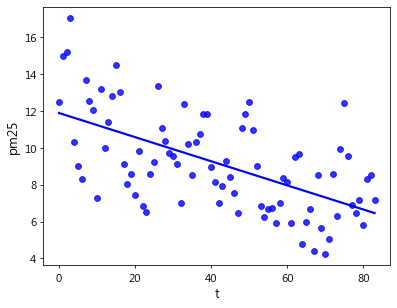

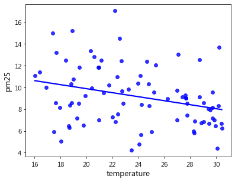

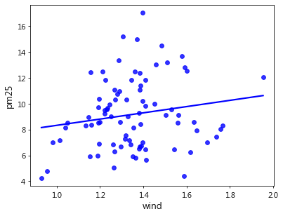

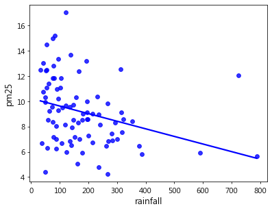

|  | pm25 | temperature | wind | rh | year_month | rainfall | t |
| --- | --- | --- | --- | --- | --- | --- | --- |
| pm25 | 1.000000 | -0.297851 | 0.170474 | -0.297373 | -0.543555 | -0.305099 | -0.591241 |
| temperature | -0.297851 | 1.000000 | 0.416452 | -0.365706 | 0.038309 | 0.202599 | 0.077966 |
| wind | 0.170474 | 0.416452 | 1.000000 | -0.719030 | -0.486830 | 0.229292 | -0.466415 |
| rh | -0.297373 | -0.365706 | -0.719030 | 1.000000 | 0.257697 | 0.243982 | 0.257220 |
| year_month | -0.543555 | 0.038309 | -0.486830 | 0.257697 | 1.000000 | 0.003733 | 0.992123 |
| rainfall | -0.305099 | 0.202599 | 0.229292 | 0.243982 | 0.003733 | 1.000000 | 0.054652 |
| t | -0.591241 | 0.077966 | -0.466415 | 0.257220 | 0.992123 | 0.054652 | 1.000000 |

```
                            OLS Regression Results
==============================================================================
Dep. Variable:                   pm25   R-squared:                       0.579
Model:                            OLS   Adj. R-squared:                  0.546
Method:                 Least Squares   F-statistic:                     17.64
Date:                Sun, 09 Jun 2024   Prob (F-statistic):           9.68e-13
Time:                        22:39:56   Log-Likelihood:                -165.54
No. Observations:                  84   AIC:                             345.1
Df Residuals:                      77   BIC:                             362.1
Df Model:                           6
Covariance Type:            nonrobust
===============================================================================
                  coef    std err          t      P>|t|      [0.025      0.975]
-------------------------------------------------------------------------------
const       -5251.7744   1803.253     -2.912      0.005   -8842.510   -1661.038
temperature    -0.1385      0.055     -2.501      0.015      -0.249      -0.028
wind           -4.8713      2.242     -2.173      0.033      -9.336      -0.407
rh             -0.3441      0.099     -3.473      0.001      -0.541      -0.147
year_month      0.0263      0.009      2.939      0.004       0.008       0.044
rainfall        0.0014      0.002      0.675      0.502      -0.003       0.006
t              -0.2826      0.074     -3.798      0.000      -0.431      -0.134
==============================================================================
Omnibus:                        3.556   Durbin-Watson:                   1.279
Prob(Omnibus):                  0.169   Jarque-Bera (JB):                3.538
Skew:                           0.480   Prob(JB):                        0.170
Kurtosis:                       2.700   Cond. No.                     1.84e+09
==============================================================================

Notes:
[1] Standard Errors assume that the covariance matrix of the errors is correctly specified.
[2] The condition number is large, 1.84e+09. This might indicate that there are
strong multicollinearity or other numerical problems.
mu = -0.001922
sigma = 1.001668
Expected frequency: [21. 21. 21. 21.]
Observed frequency: [22 25 17 20]
Chi-squared test: statistics = 1.6190 and p_value = 0.2032
Critical value = 3.841459 (defree of freedom = 1 and alpha = 0.05)
```

[figure not shown]

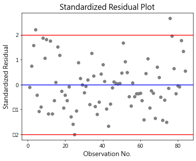

```
runs =  31
n1 =  42
n2 =  43
runs_exp = 43.494118
stan_dev = 4.581609
z = -2.727015
pval_z = 0.006391
Outliers by SD =

4     2.216106
76    2.656751
Name: SD, dtype: float64
h_level = 0.250000


Influential Observations by hi =

10    0.297472
70    0.273310
Name: hii, dtype: float64
Influential Observations by Cook's Distances =

Series([], Name: CD, dtype: float64)
x_square_sum = 84.280803
size = 84
d = 1.29
```

```python
#multiple regression
df17_1 = df.copy()

xnames = [x1_name, x2_name, x3_name, x4_name]
y_var = df17_1[y_name]
# print(df17_1[y_name].shape)
# for aname in xnames:
#     print(df17_1[aname].shape)
for aname in xnames:
    x_var = df17_1[aname].values
    _ = sns.regplot(x = x_var, y = y_var, data = df17_1, color = 'b', ci = None)
    #_ = plt.plot(x, y, 'o', color = 'b')
    plt.xlabel(aname)
    plt.ylabel(y_name)
    plt.show()

#correlation of all x and y
corr1 = df17_1.corr()
display(corr1)
_ = sns.heatmap(corr1, annot=True)

#fit model
y_data = df17_1[y_name]
# X_data_ar = np.array([df17_1.loc[:, df17_1.columns != y_name]])
# X_data_T = X_data_ar.T
# display(X_data_T)
# X_data = pd.DataFrame(X_data_T, columns = xnames)
X_data = df17_1.loc[:, df17_1.columns != y_name]
X_data2 = sm.add_constant(X_data)
olsmod = sm.OLS(y_data, X_data2)
result_reg = olsmod.fit()
print(result_reg.summary())

# standarlized residual
st1, data_stand_res, ss3 = sso.summary_table(result_reg, alpha = 0.05)
#print(ss3)
#display(st1)
SD = data_stand_res[:, 10]
mu = np.mean(SD)
sigma = np.std(SD)
#print(SD)
print(f'mu = {mu:.6f}')
print(f'sigma = {sigma:.6f}')


#normality test
chi2_pval = Chi_Square_for_Normality(SD, 4, 0.05)

#plot for Homoscedasticity or Heteroscedasticity
y_pre = data_stand_res[:, 2]
plt.plot(y_pre, SD, 'o', color = 'gray')
plt.axhline(y=2, color = 'red', lw = 0.8)
plt.axhline(y=0, color = 'blue')
plt.axhline(y=-2, color = 'red', lw = 0.8)
plt.title('Standardized Residual Plot')
plt.xlabel('Predicted y value')
plt.ylabel('Standardized Residual')
plt.show()

#plot for run test
Id1 = data_stand_res[:, 0]
plt.plot(Id1, SD, 'o', color = 'gray')
plt.axhline(y=0, color = 'blue')
plt.axhline(y=2, color = 'red')
plt.axhline(y=-2, color = 'red')
plt.title('Standardized Residual Plot')
plt.xlabel('Observation No.')
plt.ylabel('Standardized Residual')
plt.show()
#run test
SD_median = statistics.median(SD)
Z_pval = runsTest(SD, SD_median)

#outliers
df17_1_c = pd.DataFrame(SD,columns = ['SD'])
filter = (df17_1_c['SD'] < -2) | (df17_1_c['SD'] > 2)
print("Outliers by SD = \n")
#print(df17_1_c['SD'].loc[filter])
print((df17_1_c.loc[filter].set_index(df17_1_c.loc[filter].index + 1))['SD'])

#influential observations
X = np.array(X_data)
H = np.matmul(X, np.linalg.solve(np.matmul(X.T, X), X.T))
df17_1['hii'] = np.diagonal(H)
df17_1_h = pd.DataFrame(df17_1['hii'])
k = result_reg.df_model
n = len(df17_1_h['hii'])
h_level = 3 * (k+1) / n
print(f"h_level = {h_level:.6f}")
print(" \n")
filter = (df17_1_h['hii'] > h_level )
print("Influential Observations by hi = \n")
#print(df17_1_h['hii'].loc[filter])
print((df17_1_h.loc[filter].set_index(df17_1_h.loc[filter].index + 1))['hii'])

#influential observaitons by cook's distance
s2_e = result_reg.mse_resid
k = result_reg.df_model
y_a = data_stand_res[:, 1]
y_f = data_stand_res[:, 2]
h_i = df17_1['hii']
CD_arr = np.square(y_a - y_f) / s2_e / (k - 1) * h_i / np.square(1 - h_i)
CD = np.array(CD_arr)
df17_1_cd = pd.DataFrame(CD,columns = ['CD'])
#display(df17_1_cd.head())
filter = (df17_1_cd['CD'] > 1 )
print("Influential Observations by Cook's Distances = \n")
#print(df17_1_cd['CD'].loc[filter])
print((df17_1_cd.loc[filter].set_index(df17_1_cd.loc[filter].index + 1))['CD'])

#durbin watson
d_w = Durbin_Watson_test(SD)
```

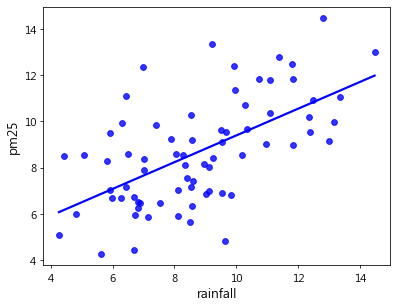

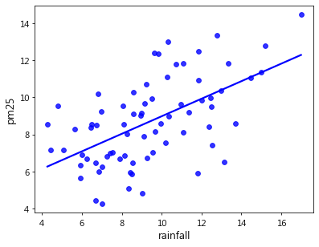

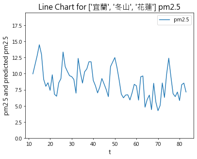

|  | pm25 | pm25_1 | pm25_12 | temperature | rainfall | rh |
| --- | --- | --- | --- | --- | --- | --- |
| 12 | 9.967213 | 13.147541 | 12.468750 | 16.906284 | 195.900000 | 80.456175 |
| 13 | 11.380952 | 9.967213 | 14.981481 | 16.423810 | 62.100000 | 78.833929 |
| 14 | 12.793548 | 11.380952 | 15.180328 | 20.599273 | 78.700000 | 73.218873 |
| 15 | 14.472222 | 12.793548 | 16.994350 | 22.564222 | 53.433333 | 75.524778 |
| 16 | 12.990399 | 14.472222 | 10.322404 | 27.065054 | 42.566667 | 75.881290 |

|  | pm25 | pm25_1 | pm25_12 | temperature | rainfall | rh |
| --- | --- | --- | --- | --- | --- | --- |
| pm25 | 1.000000 | 0.593508 | 0.569079 | -0.303326 | -0.443207 | -0.301874 |
| pm25_1 | 0.593508 | 1.000000 | 0.390537 | -0.087816 | -0.175932 | -0.006133 |
| pm25_12 | 0.569079 | 0.390537 | 1.000000 | -0.304145 | -0.133352 | -0.075269 |
| temperature | -0.303326 | -0.087816 | -0.304145 | 1.000000 | 0.177941 | -0.352376 |
| rainfall | -0.443207 | -0.175932 | -0.133352 | 0.177941 | 1.000000 | 0.352508 |
| rh | -0.301874 | -0.006133 | -0.075269 | -0.352376 | 0.352508 | 1.000000 |

```
                            OLS Regression Results
==============================================================================
Dep. Variable:                      y   R-squared:                       0.662
Model:                            OLS   Adj. R-squared:                  0.636
Method:                 Least Squares   F-statistic:                     25.82
Date:                Sun, 09 Jun 2024   Prob (F-statistic):           2.44e-14
Time:                        22:39:58   Log-Likelihood:                -123.00
No. Observations:                  72   AIC:                             258.0
Df Residuals:                      66   BIC:                             271.7
Df Model:                           5
Covariance Type:            nonrobust
===============================================================================
                  coef    std err          t      P>|t|      [0.025      0.975]
-------------------------------------------------------------------------------
const          20.8198      4.726      4.406      0.000      11.385      30.255
pm25_1          0.4207      0.077      5.432      0.000       0.266       0.575
pm25_12         0.2298      0.070      3.306      0.002       0.091       0.369
temperature    -0.1387      0.047     -2.970      0.004      -0.232      -0.045
rainfall       -0.0032      0.001     -2.128      0.037      -0.006      -0.000
rh             -0.1794      0.051     -3.498      0.001      -0.282      -0.077
==============================================================================
Omnibus:                        1.805   Durbin-Watson:                   2.181
Prob(Omnibus):                  0.405   Jarque-Bera (JB):                1.136
Skew:                           0.145   Prob(JB):                        0.567
Kurtosis:                       3.543   Cond. No.                     6.45e+03
==============================================================================

Notes:
[1] Standard Errors assume that the covariance matrix of the errors is correctly specified.
[2] The condition number is large, 6.45e+03. This might indicate that there are
strong multicollinearity or other numerical problems.
[-1.40295183 -0.3443645  -0.04635057  0.93586426  0.92616149 -0.50040885
 -0.7822544  -0.05504142 -1.06366902  0.87446219 -0.79588041 -1.99522273
  0.1713886  -0.15323392  2.06197648 -0.58521567  0.33782298  0.58007976
  0.29824263  0.76027116 -0.8125917   2.6986325  -0.30205294 -0.66600169
  0.15726549 -0.05115024  0.54377658  0.45234153  0.07841967 -0.59921086
 -1.43430068 -0.55326424  0.62093278 -0.37765639 -0.25855546 -0.71845388
  1.12042746  0.18586305  1.08517967 -0.19650624  0.13163977 -0.74503287
 -1.02342871  0.31430082 -0.42636157  0.41952764  0.353596   -0.13090581
 -0.16134091 -2.03365927  0.85268288  0.40088224 -1.58300307  0.59217293
 -0.12800186 -2.35564557  1.4064901   0.82848912 -0.33260846 -1.79530039
  0.81776401 -1.90639964  0.40804685  2.20422161  0.92793327  0.32214756
 -0.21749039  0.41367073 -0.55108302  2.38655488  0.91628925 -0.49113863]
```

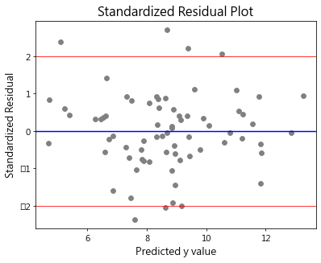

```
Shapiro Test
Statistics=0.979, p=0.265
runs =  41
n1 =  36
n2 =  37
runs_exp = 37.493151
stan_dev = 4.241424
z = 0.826809
pval_z = 0.408345

The Durbin Watson test
x_square_sum = 71.594374
size = 72
d = 2.18
```

```python
# Assuming df is already defined and contains the necessary columns.
df['pm25_1'] = df['pm25'].shift(periods=1)
df['pm25_12'] = df['pm25'].shift(periods=12)
df_autoregression = df.dropna()
y_var = df_autoregression[y_name].values

x_var = df_autoregression['pm25_1'].values
_ = sns.regplot(x = x_var, y = y_var, data = df17_1, color = 'b', ci = None)
#_ = plt.plot(x, y, 'o', color = 'b')
plt.xlabel(aname)
plt.ylabel(y_name)
plt.show()
x_var = df_autoregression['pm25_12'].values
_ = sns.regplot(x = x_var, y = y_var, data = df17_1, color = 'b', ci = None)
#_ = plt.plot(x, y, 'o', color = 'b')
plt.xlabel(aname)
plt.ylabel(y_name)
plt.show()

#plot original pm2.5
plt.plot(df_autoregression['t'], df_autoregression['pm25'])
plt.ylim(0, max(y_var)+5)
plt.legend(labels=['pm2.5'])
plt.xlabel('t')
plt.ylabel("pm2.5 and predicted pm2.5")
plt.title(f'Line Chart for {sites} pm2.5')
plt.show()

# Filter columns for the analysis
x_names = ['pm25_1', 'pm25_12', 'temperature', 'rainfall', 'rh']
df_autoregression = df_autoregression[[y_name] + x_names]
display(df_autoregression.head())

# Compute correlation matrix
corr1 = df_autoregression.corr()
display(corr1)

# Define dependent and independent variables
y_var = df_autoregression[y_name].values
X_data = df_autoregression.loc[:, df_autoregression.columns != y_name]

# Add constant to the independent variables
X_data2 = sm.add_constant(X_data)

# Fit the OLS model
df_autoregression_olsmod = sm.OLS(y_var, X_data2)
df_autoregression_result_reg = df_autoregression_olsmod.fit()
print(df_autoregression_result_reg.summary())

# Residual Analysis
df_autoregression_st, df_autoregression_data, df_autoregression_ss2 = sso.summary_table(df_autoregression_result_reg, alpha=0.05)
df_autoregression_y_pre = df_autoregression_data[:, 2]
df_autoregression_SD = df_autoregression_data[:, 10]
print(df_autoregression_SD)

plt.plot(df_autoregression_y_pre, df_autoregression_SD, 'o', color='gray')
plt.axhline(y=2, color='red', lw=0.8)
plt.axhline(y=0, color='blue')
plt.axhline(y=-2, color='red', lw=0.8)
plt.title('Standardized Residual Plot')
plt.xlabel('Predicted y value')
plt.ylabel('Standardized Residual')
plt.show()

# Shapiro Test for normality
print('Shapiro Test')
stat, p = stats.shapiro(df_autoregression_SD)
print('Statistics=%.3f, p=%.3f' % (stat, p))

df_autoregression_SD_median = statistics.median(df_autoregression_SD)
# Run's test for randomness
# Note: runsTest and Durbin_Watson_test should be defined somewhere
Z_pval = runsTest(df_autoregression_SD, df_autoregression_SD_median)

# Durbin Watson test for autocorrelation
print()
print('The Durbin Watson test')
d_w = Durbin_Watson_test(df_autoregression_SD)
```

Normality test  
H0: Errors are normally distributed.  
H1: Errors are not normally distributed.

For p-value(0.265) > significant level(0.05), we cannot reject H0. The errors are normally distributed.

Variation test H0: Homoscedasticity  
H1: Heteroscedasticity  
From the scatter diagram, do not reject H0 and the variation is constant.

Run test  
H0 : Randomness exists.  
H1 : Randomness does not exist.

Because p-value(0.408345) > significant level(0.05), we cannot reject H0.

model is above.

**臺東、關山 [雨量測站:臺東、大武、蘭嶼]**

```python
sites = ['臺東', '關山']
sites_rain = ['臺東', '大武', '蘭嶼']

df = pd.DataFrame()
first_column = pd.Series(dtype='int')
rain_column = pd.Series(dtype='float')
r = '東區'
k = 0

# Initialize an empty list to store rainfall data from all files
rainfall_data = []
rainfall_tmp = pd.DataFrame()
for site in sites_rain:
    rainfall_tmp_data = []
    # Loop through each file from 104.ods to 111.ods
    for i in range(106, 113):
        # Construct file path
        file_path = f'{i}年降雨量概況.ods'

        # Load the ODS file
        df_rain = pd.read_excel(file_path, engine='odf', header=None)

        # Search for "" in column
        search_result = df_rain[df_rain.iloc[:, 0].str.contains(site, na=False)]

        # Extract data from the row if found
        if not search_result.empty:
            # Extract data from columns G to R
            extracted_data = search_result.iloc[0, 6:18].reset_index(drop=True)

            # Create a DataFrame with "year_month" values from 2022_1 to 2022_12
            year_month = [f'{i + 1911}_{j:02}' for j in range(1, 13)]  # Adjust the year by adding 1911
            rainfall_df = pd.DataFrame({'year_month': year_month, 'rainfall': extracted_data})
            # display(rainfall_df)
            # Append the DataFrame to the list
            rainfall_tmp_data.append(rainfall_df)
    # print(rainfall_tmp_data)
    concatenated_rainfall_data = pd.concat(rainfall_tmp_data, ignore_index=True)
    # display(concatenated_rainfall_data)
    if rainfall_tmp.empty:
        rainfall_tmp = concatenated_rainfall_data.copy()
    else:
        rainfall_tmp += concatenated_rainfall_data

    first_column = concatenated_rainfall_data["year_month"]

# rainfall_data = rainfall_data / len(sites_rain)
# for df in rainfall_data:
#     df /= len(sites_rain)
rainfall_tmp["year_month"] = first_column
rainfall_tmp["rainfall"] /= len(sites_rain)
rainfall_tmp["rainfall"] = rainfall_tmp["rainfall"].astype(float)
# rainfall_data.append(rainfall_tmp)
# print(rainfall_data)

items_df = pd.DataFrame()
for site in sites:
    #get the df with items and year_month of the assigned site
    tem = aqx_df[(aqx_df["sitename"] == site) & (aqx_df["region"] == r) & (aqx_df['year'] < 2024) & (aqx_df['year'] >= 2017)]
    tem = tem.groupby(["itemname", 'year', 'month'])['concentration'].mean().reset_index()
    tem['year_month'] = tem['year'].astype(str) + '_' + tem['month'].astype(str).str.zfill(2)

    itemnames = ["溫度", "小時風速值", "細懸浮微粒", "相對濕度"]
    itemnames_en = ['temperature', 'wind', 'pm25', 'rh']
    items = [tem[["concentration", 'year_month']][tem["itemname"] == itemname].rename(columns={'concentration': itemnames_en[i]}) for i, itemname in enumerate(itemnames)]
    # print(items)
    items_df_tmp = pd.concat(items, ignore_index=True)
    df_tmp = reduce(lambda left, right: pd.merge(left, right, on='year_month', how='inner'), items)
    df_tmp = df_tmp.iloc[:,[3,0,2,4,1]]
    df_tmp = df_tmp.astype(float)
    df_tmp["year_month"] = df_tmp["year_month"].astype(int)

    # display(df_tmp)

    if items_df.empty:
        items_df = df_tmp.copy()
    else:
        items_df += df_tmp

    first_column = df_tmp["year_month"]

columns_to_include = items_df.columns.difference(['year_month'])
items_df[columns_to_include] = items_df[columns_to_include] / len(sites)
items_df['year_month'] = first_column
# display(items_df)

df = items_df.copy()
df['rainfall'] = rainfall_tmp['rainfall']
df['t'] = df.index
display(df)
```

|  | pm25 | temperature | wind | rh | year_month | rainfall | t |
| --- | --- | --- | --- | --- | --- | --- | --- |
| 0 | 7.963542 | 19.856364 | 1.321307 | 74.618755 | 201701 | 62.033333 | 0 |
| 1 | 11.533670 | 18.731053 | 1.370699 | 74.554960 | 201702 | 58.100000 | 1 |
| 2 | 11.539344 | 20.203940 | 1.203981 | 78.934806 | 201703 | 70.533333 | 2 |
| 3 | 11.705085 | 22.877037 | 1.171641 | 77.043559 | 201704 | 107.966667 | 3 |
| 4 | 7.737705 | 25.587869 | 1.158033 | 79.495574 | 201705 | 196.833333 | 4 |
| ... | ... | ... | ... | ... | ... | ... | ... |
| 79 | 4.380534 | 28.854839 | 0.756452 | 76.306452 | 202308 | 258.333333 | 79 |
| 80 | 3.838276 | 27.908333 | 0.983333 | 77.383333 | 202309 | 486.833333 | 80 |
| 81 | 5.367369 | 25.476667 | 1.145000 | 77.066667 | 202310 | 301.666667 | 81 |
| 82 | 6.250714 | 23.814286 | 1.228571 | 69.785714 | 202311 | 36.500000 | 82 |
| 83 | 4.655000 | 20.641935 | 1.237097 | 73.209677 | 202312 | 104.000000 | 83 |

84 rows × 7 columns

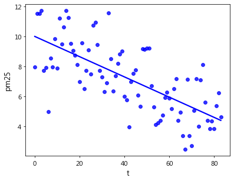

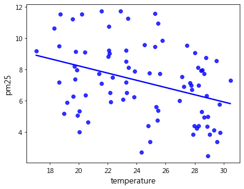

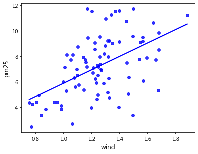

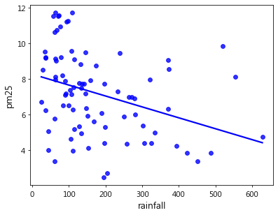

|  | pm25 | temperature | wind | rh | year_month | rainfall | t |
| --- | --- | --- | --- | --- | --- | --- | --- |
| pm25 | 1.000000 | -0.359973 | 0.526868 | 0.022218 | -0.663826 | -0.346700 | -0.699398 |
| temperature | -0.359973 | 1.000000 | -0.635158 | -0.027717 | -0.000311 | 0.480511 | 0.041451 |
| wind | 0.526868 | -0.635158 | 1.000000 | -0.141608 | -0.439938 | -0.286724 | -0.428604 |
| rh | 0.022218 | -0.027717 | -0.141608 | 1.000000 | -0.005550 | 0.298521 | -0.026516 |
| year_month | -0.663826 | -0.000311 | -0.439938 | -0.005550 | 1.000000 | 0.011743 | 0.992123 |
| rainfall | -0.346700 | 0.480511 | -0.286724 | 0.298521 | 0.011743 | 1.000000 | 0.048643 |
| t | -0.699398 | 0.041451 | -0.428604 | -0.026516 | 0.992123 | 0.048643 | 1.000000 |

```
                            OLS Regression Results
==============================================================================
Dep. Variable:                   pm25   R-squared:                       0.660
Model:                            OLS   Adj. R-squared:                  0.633
Method:                 Least Squares   F-statistic:                     24.88
Date:                Sun, 09 Jun 2024   Prob (F-statistic):           3.37e-16
Time:                        22:40:19   Log-Likelihood:                -145.21
No. Observations:                  84   AIC:                             304.4
Df Residuals:                      77   BIC:                             321.4
Df Model:                           6
Covariance Type:            nonrobust
===============================================================================
                  coef    std err          t      P>|t|      [0.025      0.975]
-------------------------------------------------------------------------------
const       -3519.0751   1578.806     -2.229      0.029   -6662.880    -375.270
temperature    -0.0167      0.077     -0.219      0.827      -0.169       0.136
wind            2.3043      1.200      1.920      0.059      -0.085       4.694
rh              0.0573      0.062      0.919      0.361      -0.067       0.181
year_month      0.0175      0.008      2.233      0.028       0.002       0.033
rainfall       -0.0036      0.001     -2.451      0.017      -0.007      -0.001
t              -0.1996      0.062     -3.197      0.002      -0.324      -0.075
==============================================================================
Omnibus:                        0.687   Durbin-Watson:                   1.716
Prob(Omnibus):                  0.709   Jarque-Bera (JB):                0.817
Skew:                          -0.156   Prob(JB):                        0.665
Kurtosis:                       2.632   Cond. No.                     2.05e+09
==============================================================================

Notes:
[1] Standard Errors assume that the covariance matrix of the errors is correctly specified.
[2] The condition number is large, 2.05e+09. This might indicate that there are
strong multicollinearity or other numerical problems.
mu = -0.003475
sigma = 1.003766
Expected frequency: [21. 21. 21. 21.]
Observed frequency: [23 17 22 22]
Chi-squared test: statistics = 1.0476 and p_value = 0.3061
Critical value = 3.841459 (defree of freedom = 1 and alpha = 0.05)
```

[figure not shown]

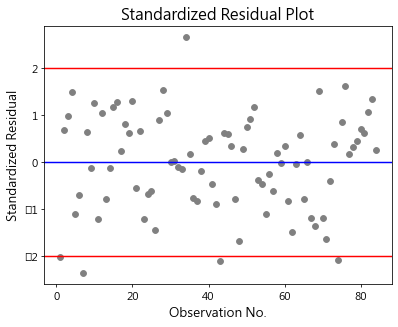

```
runs =  35
n1 =  42
n2 =  43
runs_exp = 43.494118
stan_dev = 4.581609
z = -1.853959
pval_z = 0.063745
Outliers by SD =

1    -2.027213
7    -2.349673
34    2.652426
43   -2.095762
74   -2.073223
Name: SD, dtype: float64
h_level = 0.250000


Influential Observations by hi =

Series([], Name: hii, dtype: float64)
Influential Observations by Cook's Distances =

Series([], Name: CD, dtype: float64)
x_square_sum = 84.634828
size = 84
d = 1.72
```

```python
#multiple regression
df17_1 = df.copy()

xnames = [x1_name, x2_name, x3_name, x4_name]
y_var = df17_1[y_name]
# print(df17_1[y_name].shape)
# for aname in xnames:
#     print(df17_1[aname].shape)
for aname in xnames:
    x_var = df17_1[aname].values
    _ = sns.regplot(x = x_var, y = y_var, data = df17_1, color = 'b', ci = None)
    #_ = plt.plot(x, y, 'o', color = 'b')
    plt.xlabel(aname)
    plt.ylabel(y_name)
    plt.show()

#correlation of all x and y
corr1 = df17_1.corr()
display(corr1)
_ = sns.heatmap(corr1, annot=True)

#fit model
y_data = df17_1[y_name]
# X_data_ar = np.array([df17_1.loc[:, df17_1.columns != y_name]])
# X_data_T = X_data_ar.T
# display(X_data_T)
# X_data = pd.DataFrame(X_data_T, columns = xnames)
X_data = df17_1.loc[:, df17_1.columns != y_name]
X_data2 = sm.add_constant(X_data)
olsmod = sm.OLS(y_data, X_data2)
result_reg = olsmod.fit()
print(result_reg.summary())

# standarlized residual
st1, data_stand_res, ss3 = sso.summary_table(result_reg, alpha = 0.05)
#print(ss3)
#display(st1)
SD = data_stand_res[:, 10]
mu = np.mean(SD)
sigma = np.std(SD)
#print(SD)
print(f'mu = {mu:.6f}')
print(f'sigma = {sigma:.6f}')


#normality test
chi2_pval = Chi_Square_for_Normality(SD, 4, 0.05)

#plot for Homoscedasticity or Heteroscedasticity
y_pre = data_stand_res[:, 2]
plt.plot(y_pre, SD, 'o', color = 'gray')
plt.axhline(y=2, color = 'red', lw = 0.8)
plt.axhline(y=0, color = 'blue')
plt.axhline(y=-2, color = 'red', lw = 0.8)
plt.title('Standardized Residual Plot')
plt.xlabel('Predicted y value')
plt.ylabel('Standardized Residual')
plt.show()

#plot for run test
Id1 = data_stand_res[:, 0]
plt.plot(Id1, SD, 'o', color = 'gray')
plt.axhline(y=0, color = 'blue')
plt.axhline(y=2, color = 'red')
plt.axhline(y=-2, color = 'red')
plt.title('Standardized Residual Plot')
plt.xlabel('Observation No.')
plt.ylabel('Standardized Residual')
plt.show()
#run test
SD_median = statistics.median(SD)
Z_pval = runsTest(SD, SD_median)

#outliers
df17_1_c = pd.DataFrame(SD,columns = ['SD'])
filter = (df17_1_c['SD'] < -2) | (df17_1_c['SD'] > 2)
print("Outliers by SD = \n")
#print(df17_1_c['SD'].loc[filter])
print((df17_1_c.loc[filter].set_index(df17_1_c.loc[filter].index + 1))['SD'])

#influential observations
X = np.array(X_data)
H = np.matmul(X, np.linalg.solve(np.matmul(X.T, X), X.T))
df17_1['hii'] = np.diagonal(H)
df17_1_h = pd.DataFrame(df17_1['hii'])
k = result_reg.df_model
n = len(df17_1_h['hii'])
h_level = 3 * (k+1) / n
print(f"h_level = {h_level:.6f}")
print(" \n")
filter = (df17_1_h['hii'] > h_level )
print("Influential Observations by hi = \n")
#print(df17_1_h['hii'].loc[filter])
print((df17_1_h.loc[filter].set_index(df17_1_h.loc[filter].index + 1))['hii'])

#influential observaitons by cook's distance
s2_e = result_reg.mse_resid
k = result_reg.df_model
y_a = data_stand_res[:, 1]
y_f = data_stand_res[:, 2]
h_i = df17_1['hii']
CD_arr = np.square(y_a - y_f) / s2_e / (k - 1) * h_i / np.square(1 - h_i)
CD = np.array(CD_arr)
df17_1_cd = pd.DataFrame(CD,columns = ['CD'])
#display(df17_1_cd.head())
filter = (df17_1_cd['CD'] > 1 )
print("Influential Observations by Cook's Distances = \n")
#print(df17_1_cd['CD'].loc[filter])
print((df17_1_cd.loc[filter].set_index(df17_1_cd.loc[filter].index + 1))['CD'])

#durbin watson
d_w = Durbin_Watson_test(SD)
```

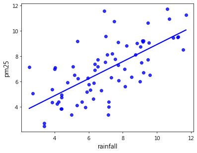

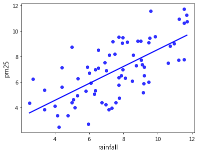

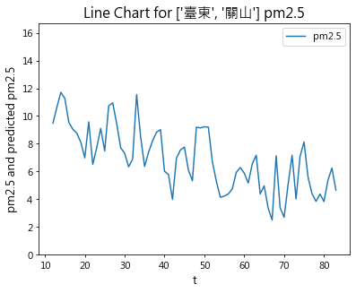

|  | pm25 | pm25_1 | pm25_12 | rainfall | wind |
| --- | --- | --- | --- | --- | --- |
| 12 | 9.475939 | 11.231487 | 7.963542 | 145.333333 | 1.567216 |
| 13 | 10.625000 | 9.475939 | 11.533670 | 61.600000 | 1.641786 |
| 14 | 11.709677 | 10.625000 | 11.539344 | 62.933333 | 1.499876 |
| 15 | 11.266667 | 11.709677 | 11.705085 | 96.566667 | 1.341000 |
| 16 | 9.534483 | 11.266667 | 7.737705 | 33.700000 | 1.259355 |

|  | pm25 | pm25_1 | pm25_12 | rainfall | wind |
| --- | --- | --- | --- | --- | --- |
| pm25 | 1.000000 | 0.683122 | 0.685623 | -0.398586 | 0.538572 |
| pm25_1 | 0.683122 | 1.000000 | 0.559033 | -0.224817 | 0.443792 |
| pm25_12 | 0.685623 | 0.559033 | 1.000000 | -0.182112 | 0.518154 |
| rainfall | -0.398586 | -0.224817 | -0.182112 | 1.000000 | -0.373116 |
| wind | 0.538572 | 0.443792 | 0.518154 | -0.373116 | 1.000000 |

```
                            OLS Regression Results
==============================================================================
Dep. Variable:                      y   R-squared:                       0.657
Model:                            OLS   Adj. R-squared:                  0.637
Method:                 Least Squares   F-statistic:                     32.14
Date:                Sun, 09 Jun 2024   Prob (F-statistic):           6.01e-15
Time:                        22:40:21   Log-Likelihood:                -121.70
No. Observations:                  72   AIC:                             253.4
Df Residuals:                      67   BIC:                             264.8
Df Model:                           4
Covariance Type:            nonrobust
==============================================================================
                 coef    std err          t      P>|t|      [0.025      0.975]
------------------------------------------------------------------------------
const          1.0068      1.052      0.957      0.342      -1.094       3.107
pm25_1         0.3716      0.087      4.266      0.000       0.198       0.545
pm25_12        0.3746      0.089      4.194      0.000       0.196       0.553
rainfall      -0.0036      0.001     -2.697      0.009      -0.006      -0.001
wind           0.8853      0.873      1.014      0.314      -0.857       2.627
==============================================================================
Omnibus:                        0.733   Durbin-Watson:                   1.882
Prob(Omnibus):                  0.693   Jarque-Bera (JB):                0.853
Skew:                           0.181   Prob(JB):                        0.653
Kurtosis:                       2.609   Cond. No.                     1.71e+03
==============================================================================

Notes:
[1] Standard Errors assume that the covariance matrix of the errors is correctly specified.
[2] The condition number is large, 1.71e+03. This might indicate that there are
strong multicollinearity or other numerical problems.
[ 0.34845915  0.41615719  1.01324647  0.52946818  0.34735727  1.36697989
  1.6632758   1.4052007  -0.12036705  1.01462427 -1.30700585 -0.69400278
  0.54270024 -1.27213896  1.15776078  0.65697076  0.49531997 -0.47088976
 -0.07633985 -0.03042119  0.60035526  2.56023716 -0.49056171 -1.100463
 -0.10958205  0.59607227  0.06818215 -0.25578129 -1.35016979 -0.8363685
 -1.91240038  1.56569706  0.55448066 -0.97984354 -1.28461699 -1.04663525
  1.67277382  0.47569163  0.35369005  0.36782765 -0.71507784 -0.41708801
 -0.49038171 -0.15642573 -0.86867987  0.2475403   0.25116727  0.22997585
 -0.85332754 -1.65569776 -0.39679652 -0.16190362 -1.16750454  0.07223008
 -1.20542778 -1.0180506   2.34228028 -1.4443558  -1.50227046 -0.34961101
  0.98037086 -2.03052425  1.04620575  0.81631254 -0.32247372 -0.0668219
  0.53879471  0.98222896 -0.45317324  1.3350542   1.00010411 -0.96888198]
```

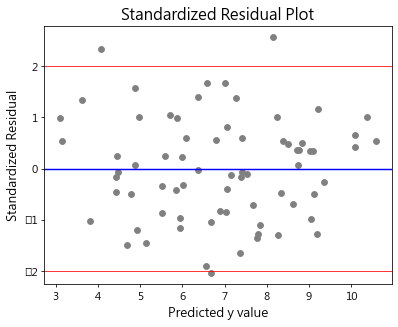

```
Shapiro Test
Statistics=0.988, p=0.699
runs =  31
n1 =  37
n2 =  36
runs_exp = 37.493151
stan_dev = 4.241424
z = -1.530889
pval_z = 0.125797

The Durbin Watson test
x_square_sum = 71.937859
size = 72
d = 1.88
```

```python
# Assuming df is already defined and contains the necessary columns.
df['pm25_1'] = df['pm25'].shift(periods=1)
df['pm25_12'] = df['pm25'].shift(periods=12)
df_autoregression = df.dropna()
y_var = df_autoregression[y_name].values

x_var = df_autoregression['pm25_1'].values
_ = sns.regplot(x = x_var, y = y_var, data = df17_1, color = 'b', ci = None)
#_ = plt.plot(x, y, 'o', color = 'b')
plt.xlabel(aname)
plt.ylabel(y_name)
plt.show()
x_var = df_autoregression['pm25_12'].values
_ = sns.regplot(x = x_var, y = y_var, data = df17_1, color = 'b', ci = None)
#_ = plt.plot(x, y, 'o', color = 'b')
plt.xlabel(aname)
plt.ylabel(y_name)
plt.show()

#plot original pm2.5
plt.plot(df_autoregression['t'], df_autoregression['pm25'])
plt.ylim(0, max(y_var)+5)
plt.legend(labels=['pm2.5'])
plt.xlabel('t')
plt.ylabel("pm2.5 and predicted pm2.5")
plt.title(f'Line Chart for {sites} pm2.5')
plt.show()

# Filter columns for the analysis
x_names = ['pm25_1', 'pm25_12', 'rainfall', 'wind']
df_autoregression = df_autoregression[[y_name] + x_names]
display(df_autoregression.head())

# Compute correlation matrix
corr1 = df_autoregression.corr()
display(corr1)

# Define dependent and independent variables
y_var = df_autoregression[y_name].values
X_data = df_autoregression.loc[:, df_autoregression.columns != y_name]

# Add constant to the independent variables
X_data2 = sm.add_constant(X_data)

# Fit the OLS model
df_autoregression_olsmod = sm.OLS(y_var, X_data2)
df_autoregression_result_reg = df_autoregression_olsmod.fit()
print(df_autoregression_result_reg.summary())

# Residual Analysis
df_autoregression_st, df_autoregression_data, df_autoregression_ss2 = sso.summary_table(df_autoregression_result_reg, alpha=0.05)
df_autoregression_y_pre = df_autoregression_data[:, 2]
df_autoregression_SD = df_autoregression_data[:, 10]
print(df_autoregression_SD)

plt.plot(df_autoregression_y_pre, df_autoregression_SD, 'o', color='gray')
plt.axhline(y=2, color='red', lw=0.8)
plt.axhline(y=0, color='blue')
plt.axhline(y=-2, color='red', lw=0.8)
plt.title('Standardized Residual Plot')
plt.xlabel('Predicted y value')
plt.ylabel('Standardized Residual')
plt.show()

# Shapiro Test for normality
print('Shapiro Test')
stat, p = stats.shapiro(df_autoregression_SD)
print('Statistics=%.3f, p=%.3f' % (stat, p))

df_autoregression_SD_median = statistics.median(df_autoregression_SD)
# Run's test for randomness
# Note: runsTest and Durbin_Watson_test should be defined somewhere
Z_pval = runsTest(df_autoregression_SD, df_autoregression_SD_median)

# Durbin Watson test for autocorrelation
print()
print('The Durbin Watson test')
d_w = Durbin_Watson_test(df_autoregression_SD)
```

Normality test  
H0: Errors are normally distributed.  
H1: Errors are not normally distributed.

For p-value(0.699) > significant level(0.05), we cannot reject H0. The errors are normally distributed.

Variation test  
H0: Homoscedasticity  
H1: Heteroscedasticity  
From the scatter diagram, do not reject H0 and the variation is constant.

Run test  
H0 : Randomness exists.  
H1 : Randomness does not exist.

Because p-value(0.125797) > significant level(0.05), we cannot reject H0.

model is above.